# Problem Set 2: Population & Marketplaces

Downloading and manipulating geospatial data to visualize populations, locations, and distances.

Author

Michael Fehl, Joan Costa, Francesco Zucca and Xènia Alemany (Group A)

Published

February 2, 2026

# Part 1: World Population

## Goals

- **Q1**. Combine the world shape world with population (point) data and with ports & airports data.
- **Q2**. Create maps & histograms regarding country-level population and average distances to nearest port/airport, segmented by continent.

## Q1.1: Combining Datasets

**Goal** : Combine the world shape world with:

- Population (point) data (do not use rasters!)
- Ports, airports, etc.

### Data

#### Data source

The data comes from two different sources, the spData library (which contains the “world” shapefile) and Natural Earth ([Data Source](https://www.naturalearthdata.com/downloads/10m-cultural-vectors/)). Specifically, from Natural Earth we download:

- Populated Places dataset
- Airports dataset
- Ports dataset

#### Data preparation

First of all, we load the datasets.

```r
sf.world <- world
st_crs(sf.world)$input
```

```
[1] "EPSG:4326"
```

```r
sf.cities <- st_read('Data/ne_10m_populated_places/ne_10m_populated_places.shp',quiet = T)
st_crs(sf.cities)$input
```

```
[1] "WGS 84"
```

```r
sf.airports <- st_read('Data/ne_10m_airports/ne_10m_airports.shp', quiet = TRUE)
st_crs(sf.airports)$input
```

```
[1] "WGS 84"
```

```r
sf.ports <- st_read('Data/ne_10m_ports/ne_10m_ports.shp', quiet = TRUE)
st_crs(sf.ports)$input
```

```
[1] "WGS 84"
```

All datasets utilise the *WGS84* coordinate reference system, hence no projection conversion is required.

For cleanliness, we filter the datasets to keep only the variables essential for this project.

```r
sf.world <- sf.world %>%
  select(name_long, continent, area_km2, geom) %>% # we are dropping pop because we will later compute it using the cities dataset
  rename(name = name_long) %>%
  # Adding type column
  mutate(type = "COUNTRY") %>%
  relocate(type, .before = everything())

sf.cities <- sf.cities %>%
  select(NAME, geometry, POP_MAX) %>% # keeping population to be able to rank the cities
  rename(name = NAME, geom = geometry, pop = POP_MAX) %>%
  # Adding type column
  mutate(type = "CITY") %>%
  relocate(type, .before = everything())

sf.airports <- sf.airports %>%
  select(name, geometry, scalerank) %>% # keeping scalerank to be able to rank the airports
  rename(geom = geometry) %>%
  # Adding type column
  mutate(type = "AIRPORT") %>%
  relocate(type, .before = everything())

sf.ports <- sf.ports %>%
  select(name, geometry, scalerank) %>%
  rename(geom = geometry) %>%
  # Adding type column
  mutate(type = "PORT") %>%
  relocate(type, .before = everything())
```

### Identifying the country for cities, airports, and ports

We need to identify the country and continent for every city, airport, and port. To do so, we will create an auxiliary dataset with only the country, continent, and geom columns of the world dataset, and then merge them based on their spatial information.

```r
# Adding country column also to the world dataset
sf.world <- sf.world %>%
  mutate(country = name)

# Creating the auxiliary dataset
sf.world.aux <- sf.world %>%
  select(country, continent, geom)

# Adding the country and continent columns to the datasets
sf.cities <- st_join(sf.cities, sf.world.aux, join = st_intersects)
mean(is.na(sf.cities$country)) * 100 # computing percentage of NAs in the country column over the total observations
```

```
[1] 6.442386
```

```r
sf.cities <- sf.cities %>%
  arrange(country)

sf.airports <- st_join(sf.airports, sf.world.aux, join = st_intersects)
mean(is.na(sf.airports$country)) * 100
```

```
[1] 11.64614
```

```r
sf.airports <- sf.airports %>%
  arrange(country)

sf.ports <- st_join(sf.ports, sf.world.aux, join = st_intersects)
mean(is.na(sf.ports$country)) * 100
```

```
[1] 28.58464
```

```r
sf.ports <- sf.ports %>%
  arrange(country)
```

Our operation generated a lot of `NA`’s, especially in the airport and port datasets. This probably happens because some coastal locations are mapped slightly outside the country borders. Therefore, when using st_intersect, they don’t intersect with any country in the world dataset, generating `NA`’s.

To fix this, we will undo the last step and try again using a 10km buffer.

```r
# Reverting to the original datasets
sf.airports <- sf.airports %>%
  select(- country, - continent)

sf.ports <- sf.ports %>%
  select(- country, - continent)

# Adding the country and continent columns to the datasets
sf.airports <- st_join(sf.airports, sf.world.aux, join = st_is_within_distance, dist = 10000)
sf.airports <- sf.airports %>%
  arrange(country)
mean(is.na(sf.airports$country)) * 100
```

```
[1] 7.359307
```

```r
sf.ports <- st_join(sf.ports, sf.world.aux, join = st_is_within_distance, dist = 10000)
sf.ports <- sf.ports %>%
  arrange(country)
mean(is.na(sf.ports$country)) * 100
```

```
[1] 10.05435
```

This buffer fixed a lot of the missing values. However, this operation may not be totally accurate. For example, since some small islands are missing from our world map, a port may be assigned to the wrong country if it is withing 10km of its borders. Also, ports on islands that are further than 10 km away from the coastline are still not detected.

```r
# Aggregating population by country
country_pop <- sf.cities %>%
  st_drop_geometry() %>% # dropping geometry since we don't need it for this
  group_by(country) %>%
  # Summing pop column of cities in the same country
  summarise(pop = sum(pop, na.rm = TRUE))

# Joining the calculated population to the world dataset
sf.world <- sf.world %>%
  left_join(country_pop, by = "country") %>%
# Moving geom to the last column for tidyness
  relocate(geom, .after = everything())
```

Now we will merge the datasets into one single dataset.

```r
sf.data <- bind_rows(sf.world, sf.cities, sf.airports, sf.ports)

# Rearrange by type
sf.data <- sf.data %>%
  arrange(type)
```

## Q1.2: World Map & Histograms

Produce:

- Map of total population by country
- Histogram of country population distribution by continent
- Histogram of (country-level) average distances between locations and ports or airports by continent. If there are too many locations and/or airports, filter the top 20 of them.

For ease of use and code tidiness, we will use the unmerged datasets.

### Classification of Cities

OECD [classifies urban areas as](https://www.oecd.org/en/data/indicators/urban-population-by-city-size.html):

- large metropolitan areas if they have a population of 1.5 million or more;
- metropolitan areas if their population is between 500 000 and 1.5 * million;
- medium-size urban areas if their population is between 200 000 and 500 000; and,
- small urban areas if their population is between 50 000 and 200 000.

- Megacities (population greater than 10M)
- Towns (population from 5k to 50k)
- Villages (population lower than 5k)

Our categories are:

- Very low (< 5k population)
- Low (5k to 50k population)
- Medium-Low (50k to 200k population)
- Medium (200k to 500k population)
- Medium-High (500k to 1.5M population)
- High (1.5M to 10M population)
- Very high (> 10M population)

```r
sf.cities <- sf.cities %>%
  mutate(pop_cat = cut( # creating categorical column for population
    pop,
    # Binning the population data
    breaks = c(- Inf, 5000, 50000, 200000, 500000,
               1500000, 10000000, Inf),
    # Adding labels
    labels = c("Very Low", "Low", "Medium-Low", "Medium", "Medium-High",
               "High", "Very high"),
    right = FALSE
  ))

st_drop_geometry(sf.cities) %>%
  count(pop_cat) # See if some categories do not contain many cities
```

```
      pop_cat    n
1    Very Low  854
2         Low 2273
3  Medium-Low 2188
4      Medium 1020
5 Medium-High  702
6        High  286
7   Very high   19
```

### Plotting

To keep the map readable, we will limit the number of cities shown for each country based on its size. Larger countries will show more cities, while smaller countries will show fewer

```r
# Auxiliary dataset
country_data <- sf.world %>%
  st_drop_geometry() %>%
  select(country, area_km2) # Keep only what we need

# Filtering cities based on Country Size
sf.cities.plot <- sf.cities %>%
  # Join the area data to the cities
  left_join(country_data, by = "country") %>%

  # Define the "City Limit" rules
  mutate(
    max_cities = case_when(
      area_km2 < 20000   ~ 1,
      area_km2 < 100000  ~ 3,
      area_km2 < 350000  ~ 6,
      area_km2 < 1000000 ~ 10,
      area_km2 < 5000000 ~ 15,
      TRUE               ~ 25
    )
  ) %>%

  # Applying the filter
  group_by(country) %>%
  arrange(desc(pop)) %>%                # Sort largest to smallest
  filter(row_number() <= max_cities) %>% # Keep only the allowed amount
  ungroup()
```

Finally, we generate our plot.

**Show the plotting code**

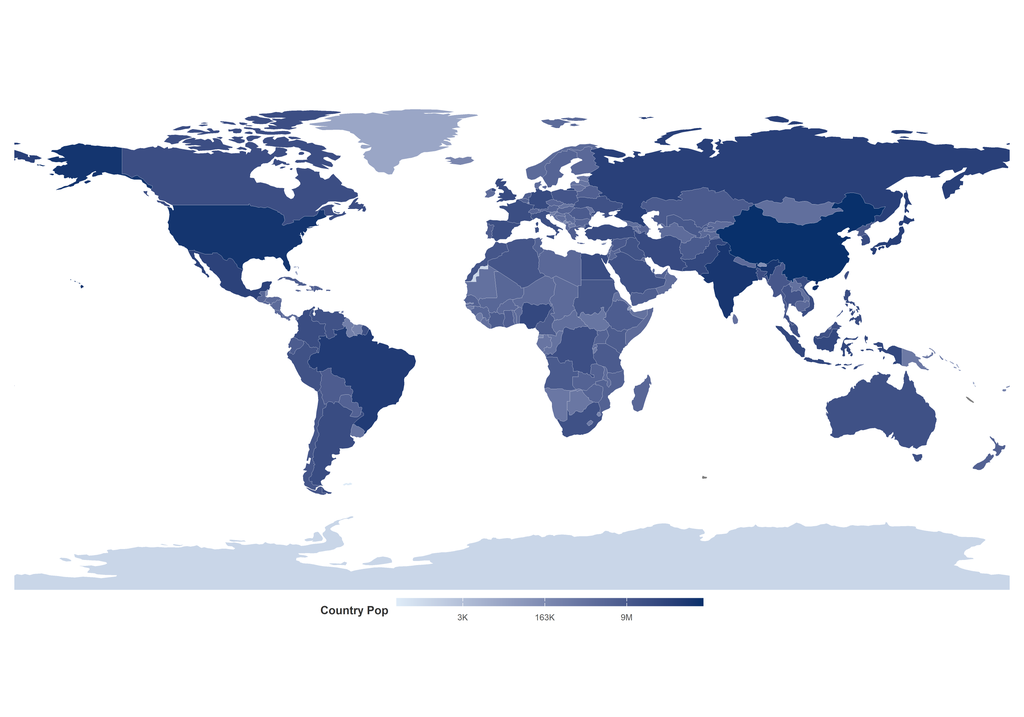

```r
# Plotting
ggplot() +

  # World map
  geom_sf(data = sf.world, aes(fill = pop), color = "white", size = 0.05) +
  scale_fill_gradient( # gradient based on the country's population
    low = "#deebf7",
    high = "#08306b",
    name = "Country Pop",
    trans = "log", # logarithmic scale so that the gradient is not completely skewed towards China and India
    labels = scales::label_number(scale_cut = scales::cut_short_scale()), # formatting the labels to make them more readable
    guide = guide_colorbar(
      title.position = "left",
      title.hjust = 0.5,
      barwidth = 15,
      barheight = 0.4,
      order = 1
    )
  ) +

  guides(
    # Hiding shape and size legends
    shape = "none",
    size  = "none",

    # Keepig the color and putting title on Left
    color = guide_legend(
      title.position = "left",
      title.vjust = 0.5,
      nrow = 1,
      order = 2)) +

  # Cleaning
  coord_sf(datum = NA, expand = FALSE) +
  theme_void() +
  theme(

    # Legend
    legend.position = "bottom",
    legend.box = "vertical",
    legend.margin = margin(t = 10, b = 10, l = 10, r = 10),
    legend.box.margin = margin(t = -10, b = -10, l = 0, r = 0),

    # Image margins
    plot.margin = margin(t = 10, r = 10, b = 0, l = 10, unit = "pt"),

    # Text styles
    legend.title = element_text(size = 8, face = "bold", color = "grey20"),
    legend.text = element_text(size = 6, color = "grey30"),
    legend.key.size = unit(0.4, "cm")
  )
```

As a bonus, we can also visualize the world population map with the cities used to generate the population counts in each country, by their classifications:

**Show the plotting code**

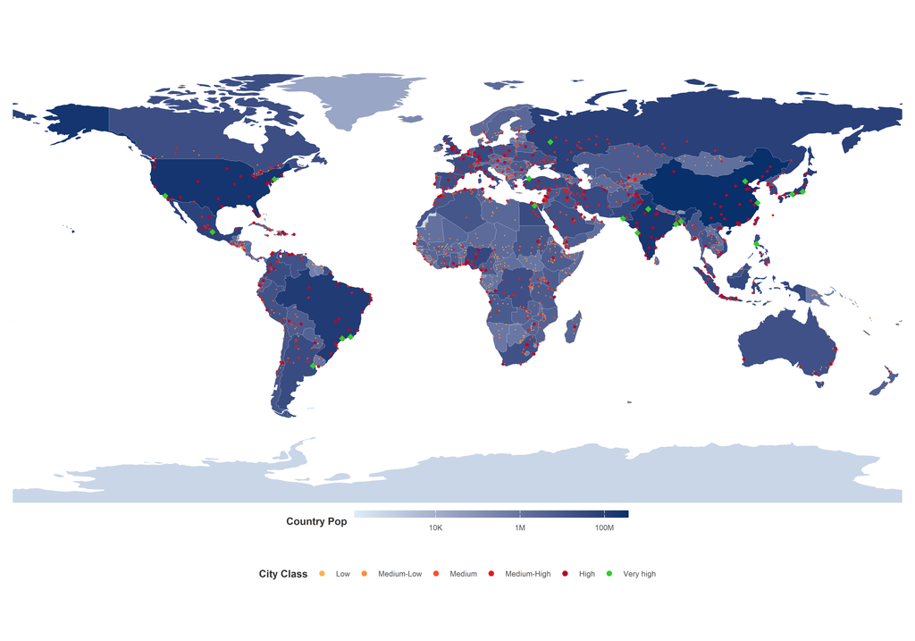

```r
# Defining custom shapes and colors
city_shapes <- c(
  "Very low" = 16, "Low" = 16, "Medium-Low" = 16,
  "Medium" = 16, "Medium-High" = 16, "High" = 16,
  "Very high" = 18
)

city_colors <- c(
  "Very low"    = "#ffeda0",
  "Low"         = "#feb24c",
  "Medium-Low"  = "#fd8d3c",
  "Medium"      = "#fc4e2a",
  "Medium-High" = "#e31a1c",
  "High"        = "#bd0026",
  "Very high"   = "#32cd32"
)

# Plotting
ggplot() +

  # World map
  geom_sf(data = sf.world, aes(fill = pop), color = "white", size = 0.05) +
  scale_fill_gradient( # gradient based on the country's population
    low = "#deebf7",
    high = "#08306b",
    name = "Country Pop",
    trans = "log10", # logarithmic scale so that the gradient is not completely skewed towards China and India
    labels = scales::label_number(scale_cut = scales::cut_short_scale()), # formatting the labels to make them more readable
    guide = guide_colorbar(
      title.position = "left",
      title.hjust = 0.5,
      barwidth = 15,
      barheight = 0.4,
      order = 1
    )
  ) +

  # Cities
  geom_sf(
    data = sf.cities.plot %>% arrange(pop_cat),
    aes(color = pop_cat, shape = pop_cat, size = pop_cat),
    alpha = 1
  ) +

  # Scales
  scale_shape_manual(values = city_shapes, name = "City Class") +
  scale_color_manual(values = city_colors, name = "City Class") +
  scale_size_manual(values = c(0.05, 0.1, 0.2, 0.3, 0.5, 0.8, 2), name = "City Class") +

  guides(
    # Hiding shape and size legends
    shape = "none",
    size  = "none",

    # Keepig the color and putting title on Left
    color = guide_legend(
      title.position = "left",
      title.vjust = 0.5,
      nrow = 1,
      order = 2)) +

  # Cleaning
  coord_sf(datum = NA, expand = FALSE) +
  theme_void() +
  theme(

    # Legend
    legend.position = "bottom",
    legend.box = "vertical",
    legend.margin = margin(t = 10, b = 10, l = 10, r = 10),
    legend.box.margin = margin(t = -10, b = -10, l = 0, r = 0),

    # Image margins
    plot.margin = margin(t = 10, r = 10, b = 0, l = 10, unit = "pt"),

    # Text styles
    legend.title = element_text(size = 8, face = "bold", color = "grey20"),
    legend.text = element_text(size = 6, color = "grey30"),
    legend.key.size = unit(0.4, "cm")
  )
```

#### Histogram of country population distribution by continent

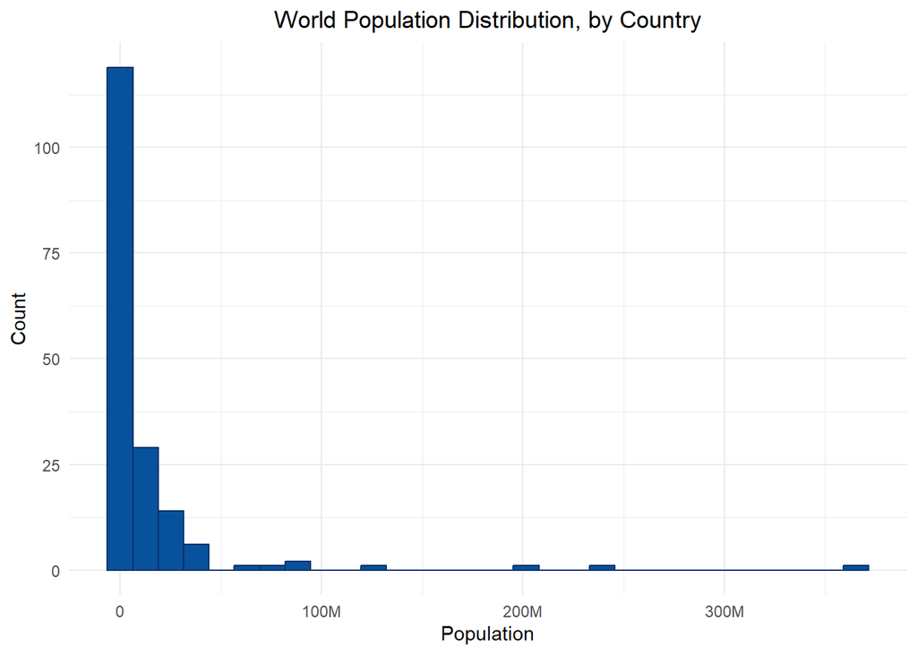

```r
# Filter the data set to have only population and joint everything by country

sf.data_pop <- sf.data %>%
  filter(type == 'CITY') %>%
  group_by(country) %>%
  summarize(population = sum(pop))

ggplot(sf.data_pop, aes(x = population)) +
  geom_histogram(bins = 30, colour = '#08306b', fill = '#08519c') +
  labs(x = 'Population',
       y = 'Count',
       title = 'World Population Distribution, by Country') +
  scale_x_continuous(
    labels = c("0", "100M", "200M", "300M"),
    breaks = c(0, 100000000, 200000000, 300000000)
  ) +
  theme_minimal()+
  theme(plot.title = element_text(hjust=0.5))
```

```r
extremes <- sf.data_pop %>%
  filter(population > 50000000)
```

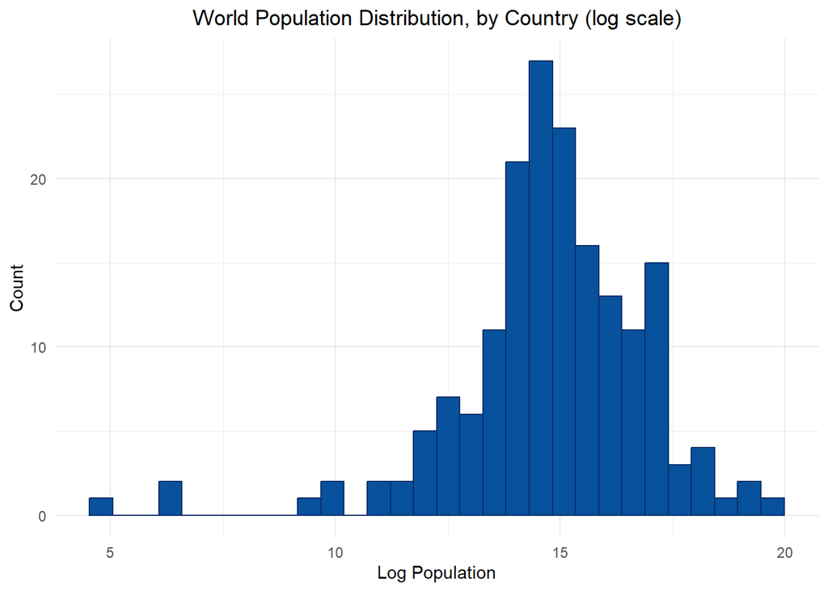

```r
# Compute the log of the population variable

sf.data_pop <- sf.data_pop %>%
  mutate(log_pop = log(population))

ggplot(sf.data_pop, aes(x = log_pop)) +
  geom_histogram(bins = 30, colour = '#08306b', fill = '#08519c') +
  labs(x = 'Log Population',
       y = 'Count',
       title = 'World Population Distribution, by Country (log scale)') +
  theme_minimal() +
  theme(plot.title = element_text(hjust=0.5))
```

#### By continents

To have a more detailed information on the population density we decided to compute the same log histograms for each of the continents.

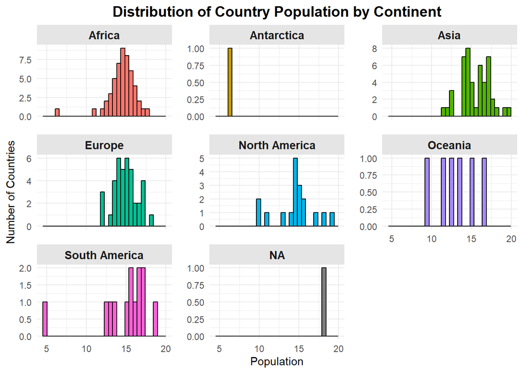

```r
sf.data_pop <- sf.data_pop %>%
  left_join(sf.world.aux %>%
              st_drop_geometry() %>%
              select(country, continent),
            by = 'country')

ggplot(sf.data_pop, aes(x = log_pop)) +
  geom_histogram(bins = 30, aes(fill = continent), colour = 'black') +
  facet_wrap(~ continent, scales = "free_y") +
  labs(
    title = 'Distribution of Country Population by Continent',
    x = 'Population',
    y = 'Number of Countries'
  ) +
  theme_minimal() +
  theme(
    plot.title = element_text(face = "bold", size = 14, hjust=0.5),
    plot.subtitle = element_text(size = 11, color = "gray40", hjust=0.5),
    strip.text = element_text(face = "bold", size = 11),
    strip.background = element_rect(fill = "gray90", colour = NA),
    panel.spacing = unit(1, "lines"),
    legend.position = "none"
  )
```

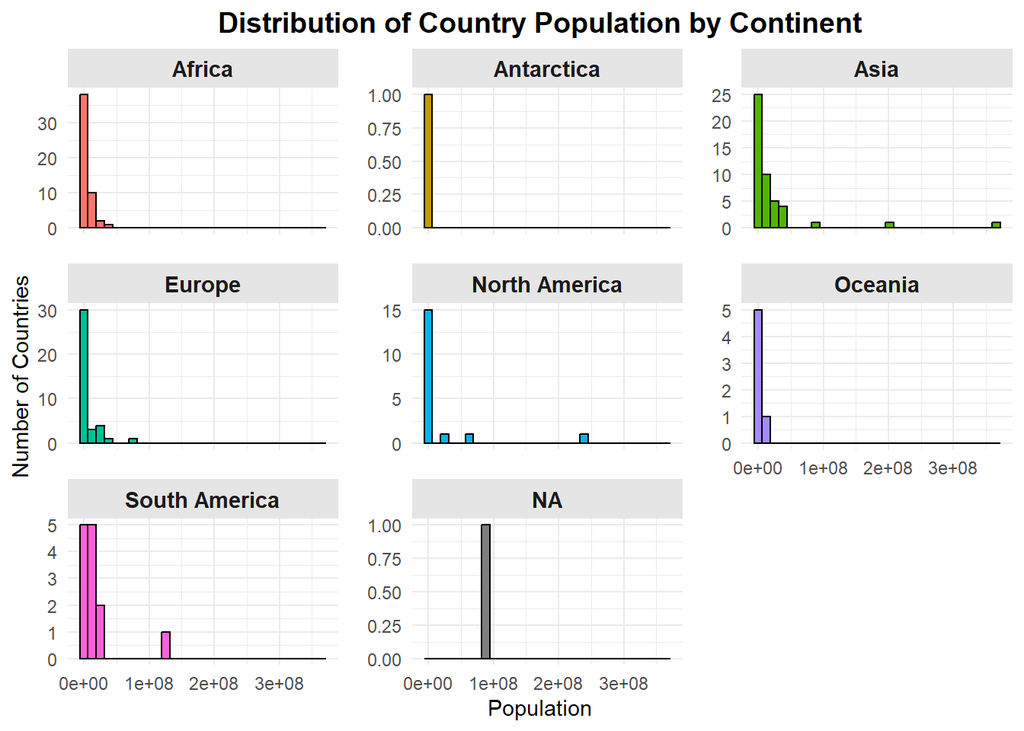

```r
ggplot(sf.data_pop, aes(x = population)) +
  geom_histogram(bins = 30, aes(fill = continent), colour = 'black') +
  facet_wrap(~ continent, scales = "free_y") +
  labs(
    title = 'Distribution of Country Population by Continent',
    x = 'Population',
    y = 'Number of Countries'
  ) +
  theme_minimal() +
  theme(
    plot.title = element_text(face = "bold", size = 14, hjust=0.5),
    plot.subtitle = element_text(size = 11, color = "gray40", hjust=0.5),
    strip.text = element_text(face = "bold", size = 11),
    strip.background = element_rect(fill = "gray90", colour = NA),
    panel.spacing = unit(1, "lines"),
    legend.position = "none"
  )
```

#### Histogram of (country-level) average distances between locations and ports or airports by continent.

```r
# Use data set sf.data
# Compute distance between cities and ports and airports by country
# Combine ports and airports
library(units)
sf.transport <- sf.data %>% filter(type %in% c('PORT', 'AIRPORT'))
sf.locations <- sf.data %>% filter(type == 'CITY')

# Calculate distance matrix to all transport hubs
distance_matrix <- st_distance(sf.locations$geom, sf.transport$geom)

# Get minimum distance for each city
sf.locations <- sf.locations %>%
  mutate(
    distance_to_nearest = apply(distance_matrix, 1, min),
    distance_km = as.numeric(distance_to_nearest) / 1000   # Convert to km
  )

# Calculate country-level averages
country_distances <- sf.locations %>%
  st_drop_geometry() %>%
  group_by(country, continent) %>%
  summarize(avg_distance_km = mean(distance_km, na.rm = TRUE),
            .groups = 'drop') %>%
  filter(!is.na(continent))
```

**Show the plotting code**

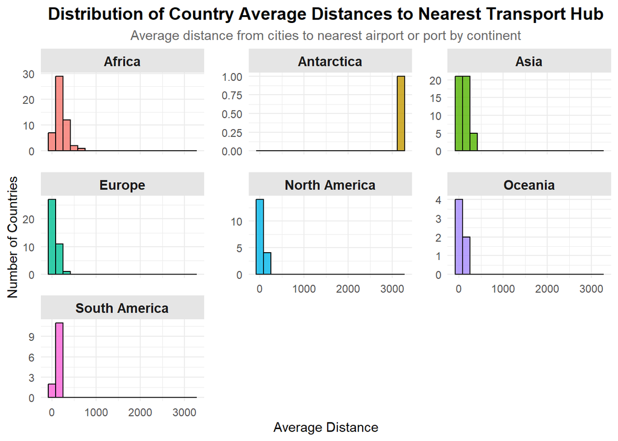

```r
# plot
ggplot(country_distances, aes(x = avg_distance_km)) +
  geom_histogram(bins = 20, aes(fill = continent), colour = 'black', alpha = 0.8) +
  facet_wrap(~ continent, scales = "free_y") +
  labs(
    title = 'Distribution of Country Average Distances to Nearest Transport Hub',
    subtitle = 'Average distance from cities to nearest airport or port by continent',
    x = 'Average Distance',
    y = 'Number of Countries'
  ) +
  theme_minimal() +
  theme(
    plot.title = element_text(face = "bold", size = 14, hjust=0.5),
    plot.subtitle = element_text(size = 11, color = "gray40", hjust=0.5),
    strip.text = element_text(face = "bold", size = 11),
    strip.background = element_rect(fill = "gray90", colour = NA),
    panel.spacing = unit(1, "lines"),
    legend.position = "none"
  )
```

With the average distance in km for each continent, we cannot extract much information when we compare the distribution across continents. We take the log again.

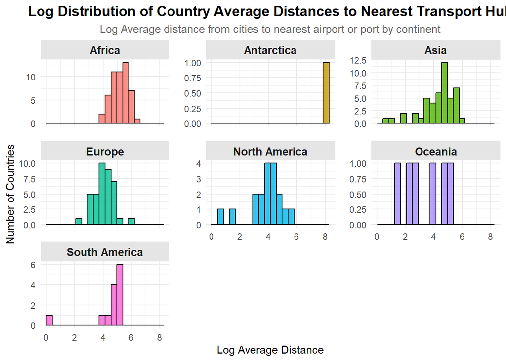

```r
ggplot(country_distances, aes(x = log(avg_distance_km))) +
  geom_histogram(bins = 20, aes(fill = continent), colour = 'black', alpha = 0.8) +
  facet_wrap(~ continent, scales = "free_y") +
  labs(
    title = 'Log Distribution of Country Average Distances to Nearest Transport Hub',
    subtitle = 'Log Average distance from cities to nearest airport or port by continent',
    x = 'Log Average Distance',
    y = 'Number of Countries'
  ) +
  theme_minimal() +
  theme(
    plot.title = element_text(face = "bold", size = 14, hjust=0.5),
    plot.subtitle = element_text(size = 11, color = "gray40", hjust=0.5),
    strip.text = element_text(face = "bold", size = 11),
    strip.background = element_rect(fill = "gray90", colour = NA),
    panel.spacing = unit(1, "lines"),
    legend.position = "none"
  )
```

From the plots above using the log transformation, several insights can be highlighted. Africa shows higher average distances between cities and transport hubs compared to Europe, which may reflect less developed infrastructure, greater geographic dispersion of cities, or the continent’s larger land area. Europe and North America present similar distributions, with most countries clustered at lower average distances, suggesting well-developed and accessible transport networks.

# Part 2: Markets in Africa

## Goals

**Q1**. Generate an sf POINT feature of marketplaces across Africa; plot them

**Q2**. Calculate minimum distance of each market to the (i) coast, (ii) nearest road, and (iii) nearest airport

**Q3**. Produce 3 scatter plots relating average prices with the minimum distances

### Reference Paper:

Porteous, O., 2019. High trade costs and their consequences: An estimated dynamic model of African agricultural storage and trade. American Economic Journal: Applied Economics, 11(4), pp.327-66.

Direct link: [Paper](https://www.aeaweb.org/articles?id=10.1257/app.20170442)

### Packages used:

```r
rm(list=ls())
library(sf)
library(tidyverse)
library(spData)
library(osmdata)
library(readxl)
```

## Data and sources

To complete this assignment, we will need data from several sources. First, we will use the `spData` library, which contains the world shapefile. In addition, we will need datasets for roads, highways, airports, and the coastline, as well as data from the replication paper that features marketplaces across Africa.

Sources:

- [Airports](https://www.naturalearthdata.com/downloads/10m-cultural-vectors/airports/)
- [Highways and Roads](https://bulk.openafrica.net/dataset/road-network1)
- [Coastline](https://www.naturalearthdata.com/downloads/10m-physical-vectors/10m-coastline/)
- [Market Locations and Prices](https://www.openicpsr.org/openicpsr/project/116359/version/V1/view)

### Loading the Data

First we create a polygon from the world shape file in `spData` so we can use it to filter through intersections with other datasets

```r
africa <- world %>%  filter(continent == "Africa")

africa_poly <- africa %>%
  summarise(geom = st_union(geom), .groups = "drop")
```

We load the different shapefiles for the roads, the coastline and the airports:

```r
africa_roads_raw<-st_read("Data/groads-v1-africa-shp/gROADS-v1-africa.shp", quiet = TRUE) #Roads data

africa_roads_clean<- africa_roads_raw %>%
  filter(LENGTH_KM >= 20) %>%
  st_crop(africa_poly) %>%
  st_intersection(africa_poly)

coastline<-st_read("Data/ne_10m_coastline/ne_10m_coastline.shp", quiet = TRUE)
coastline_africa <- st_intersection(coastline, africa)



airports<-st_read("Data/ne_10m_airports/ne_10m_airports.shp", quiet = TRUE)
airports_africa  <- st_intersection(airports, africa)
```

For the Africa roads layer, we apply two filters. First, we keep only roads with `LENGTH_KM >= 20` so that smaller roads are not considered. We choose this for a couple of reasons; first, because computationally it is very expensive to compute intersections and distances for over 500k+ road observations, so reducing the size of this dataset is beneficial to the efficiency of our task execution; second, because this is a much more relevant analysis of the data – we care more about the distance a market has to a more important, well-connected road than it does to some random neighborhood or back road that may only spans one kilometer and connects to very few homes.

Second, we clip the roads to the Africa polygon (`africa_poly`) derived from the world dataset, because the roads shapefile also includes features from the Middle East and the southern part of Europe. We use `st_intersection()` for an exact spatial clip to Africa and we apply the same concept to the coastline data and the airports data.

## Q2.1: Plot Marketplaces

First, we load the data from the market places from the replication package:

```r
# 1) Obtaining the coordinates
coords <- read_excel("Data/markets/MktCoords.xlsx", sheet = "MarketCoordinates")

# 2) Convert to sf points
mkt_pts <- st_as_sf(coords, coords = c("longitude", "latitude"), crs = 4326)
```

#### Constructing the plot

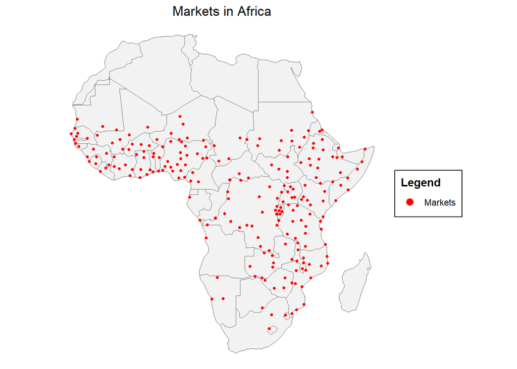

```r
ggplot() +
  geom_sf(data = africa, fill = "grey95", color = "grey40", linewidth = 0.3) +
  geom_sf(data = mkt_pts, aes(color = "Markets"), size = 1) +
  scale_color_manual(
    name = "Legend",
    values = c("Markets" = "red")
  ) +
  guides(
    color = guide_legend(
      override.aes = list(size = 3, shape = 16)
    )
  ) +
  labs(title = "Markets in Africa")+
  theme_void() +
  theme(
    legend.background = element_rect(fill = "white", color = "black", linewidth = 0.5),
    legend.margin = margin(6, 6, 6, 6),
    legend.title = element_text(face = "bold"),
    plot.title = element_text(hjust=0.5)
  )
```

To construct this plot, we use a filtered Africa polygon obtained from the world dataset in the spData package, together with market location points from the replication data. The figure shows that all marketplaces are located south of the Sahara Desert, with particularly high concentrations in a subset of countries.

## Q2.2: Calculate Min Distances

We can combine what we have obtained before with the roads data to obtain the following plot:

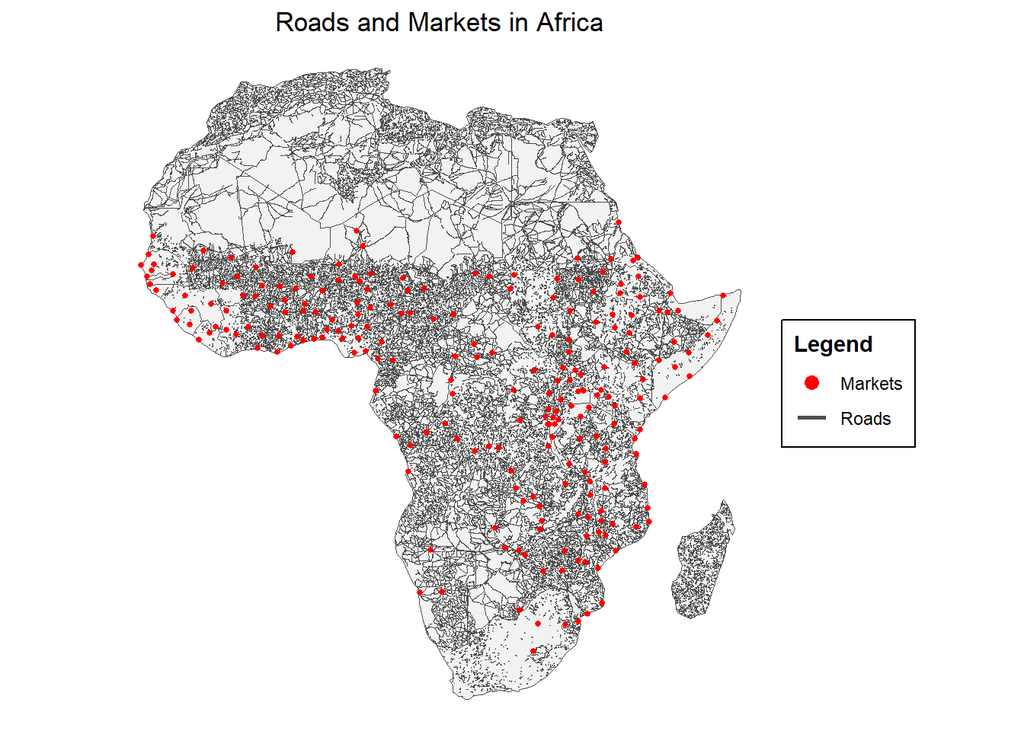

```r
ggplot() +
  geom_sf(data = africa, fill = "grey95", color = "grey30", linewidth = 0.3) +
  geom_sf(data = africa_roads_clean, aes(color = "Roads"),
          linewidth = 0.3, key_glyph = draw_key_path) +
  geom_sf(data = mkt_pts, aes(color = "Markets"), size = 1) +
  scale_color_manual(
    name = "Legend",
    values = c(
      "Markets" = "red",
      "Roads"   = "grey30"
    ),
    breaks = c("Markets", "Roads")
  ) +
  guides(
    color = guide_legend(
      override.aes = list(
        linewidth = c(0, 1),
        shape     = c(16, NA),
        size      = c(3, 0)
      )
    )
  ) +
  labs(title = "Roads and Markets in Africa") +
  theme_void() +
  theme(
    legend.background = element_rect(fill = "white", color = "black", linewidth = 0.5),
    legend.margin = margin(6, 6, 6, 6),
    legend.title = element_text(face = "bold"),
    plot.title = element_text(hjust=0.5)
  )
```

And combine the previous plot with the the coast and airport data:

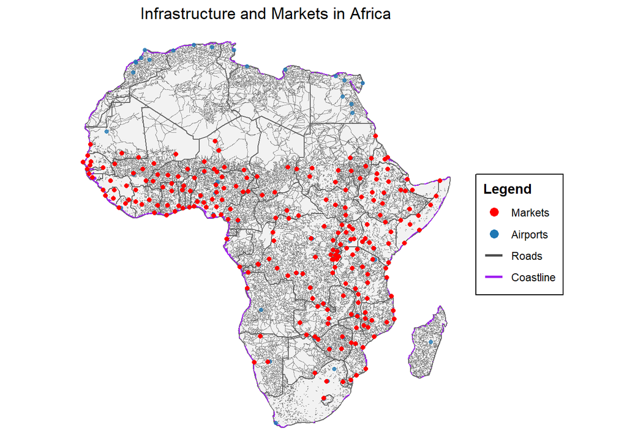

```r
ggplot() +
  # Africa background
  geom_sf(data = africa, fill = "grey95", color = "grey40", linewidth = 0.4) +

  # Roads
  geom_sf(
    data = africa_roads_clean,
    aes(color = "Roads"),
    linewidth = 0.3,
    alpha = 0.6,
    key_glyph = draw_key_path
  ) +

  # Coastline
  geom_sf(
    data = coastline_africa,
    aes(color = "Coastline"),
    linewidth = 0.4,
    key_glyph = draw_key_path
  ) +

  # Airports
  geom_sf(
    data = airports_africa,
    aes(color = "Airports"),
    size = 1.2,
    alpha = 0.8
  ) +

  # Market points
  geom_sf(
    data = mkt_pts,
    aes(color = "Markets"),
    size = 1.5
  ) +

  scale_color_manual(
    name = "Legend",
    values = c(
      "Roads"     = "grey30",
      "Coastline" = "purple",
      "Airports"  = "#1f78b4",
      "Markets"   = "red"
    ),
    breaks = c("Markets", "Airports", "Roads", "Coastline")
  ) +

  guides(
    color = guide_legend(
      override.aes = list(
        linewidth = c(0, 0, 1, 1),
        shape     = c(16, 16, NA, NA),
        size      = c(3, 3, 0, 0),
        alpha     = c(1, 1, 1, 1)
      )
    )
  ) +
  labs(title = "Infrastructure and Markets in Africa") +
  theme_void() +
  theme(
    plot.background = element_rect(fill = "white", color = NA),
    legend.background = element_rect(fill = "white", color = "black", linewidth = 0.5),
    legend.margin = margin(6, 6, 6, 6),
    legend.title = element_text(face = "bold"),
    plot.title = element_text(hjust=0.5)
  )
```

#### Computing the distances

To compute the minimum distance:

```r
# Nearest feature index for each market
idx_coast   <- st_nearest_feature(mkt_pts, coastline_africa)
idx_road    <- st_nearest_feature(mkt_pts, africa_roads_clean)
idx_airport <- st_nearest_feature(mkt_pts, airports_africa)
```

We want the minimum distance for each market individually and we want to compute it efficiently and correctly, without building a huge distance matrix or mixing markets together, `st_nearest_feature()` tells us which feature is the closest one to each market.

Then we compute the distance only to that feature:

```r
# Minimum distance (meters) to the nearest feature (by element)
d_coast_m <- st_distance(mkt_pts, coastline_africa[idx_coast, ], by_element = TRUE)
d_road_m  <- st_distance(mkt_pts, africa_roads_clean[idx_road, ],      by_element = TRUE)
d_air_m   <- st_distance(mkt_pts, airports_africa[idx_airport,], by_element = TRUE)

# Attach to the markets table (convert to numeric km)
mkt_pts <- mkt_pts %>%
  mutate(
    dist_coast_km   = as.numeric(d_coast_m) / 1000,
    dist_road_km    = as.numeric(d_road_m)  / 1000,
    dist_airport_km = as.numeric(d_air_m)   / 1000
  )
```

For each market location, we compute the minimum Euclidean distance to the three types of spatial infrastructure: the coastline, the road network, and the nearest airport. This is done using the `st_distance()` function.

Before computing distances, each market is matched to its nearest feature of the relevant type (coast, road, or airport). Using these matches, `st_distance()` is applied with the option `by_element = TRUE`, which ensures that distances are calculated pairwise, which makes that each market is compared only to its own nearest feature rather than to all features in the dataset. As a result, the output is a vector of minimum distances, one value per market, expressed in meters, which correspond to the coordinate reference system of the spatial data.

The resulting distance vectors are then added to the markets dataset as new variables. Distances are converted from meters to kilometers by dividing by 1,000 and stored in three different variables: distance to the coast, distance to the nearest road, and distance to the nearest airport.

We can check the mean distances for each of the three variables:

```r
summary(mkt_pts$dist_coast_km)
```

```
     Min.   1st Qu.    Median      Mean   3rd Qu.      Max.
   0.1478  178.1537  530.0659  571.5270  925.7852 1736.1293
```

```r
summary(mkt_pts$dist_road_km)
```

```
     Min.   1st Qu.    Median      Mean   3rd Qu.      Max.
7.255e-03 9.458e-01 3.044e+00 1.165e+01 1.069e+01 1.238e+02
```

```r
summary(mkt_pts$dist_airport_km)
```

```
   Min. 1st Qu.  Median    Mean 3rd Qu.    Max.
   1.11   24.30  201.73  229.19  338.24  915.61
```

It can be seen that each variable has very different interpretation as its values vary deeply:

- Distance to coast: On average, markets are located about **572km** from the coastline, indicating that many markets are substantially inland.
- Distance to roads: Markets are, on average, about **11.7km** away from the nearest major road, suggesting relatively good road accessibility (We have to consider the filter of minimum 20km length applied in the beginning for the roads for this interpretation, which means that if the filter was not applied we could expect a lower distance on average).
- Distance to airports: The average distance to the nearest airport is approximately **229km**, implying limited proximity to air transport infrastructure for most markets.

We could also inspect an specific market row:

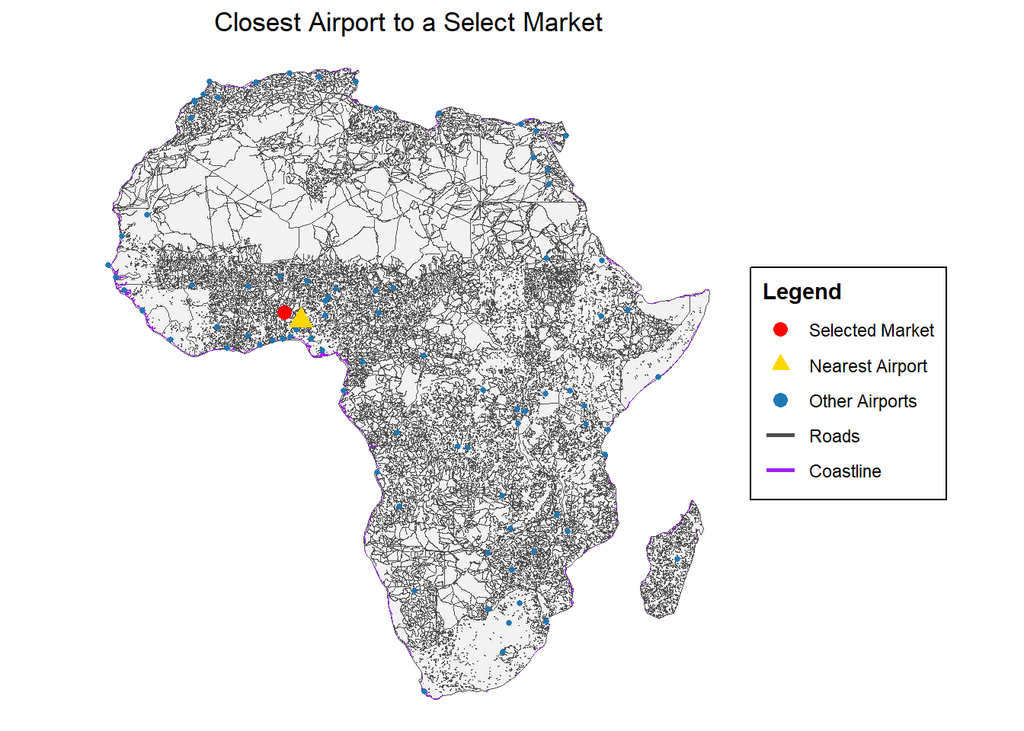

```r
i <- 5  # pick a market row to inspect

# ggplot() +
#   geom_sf(data = africa, fill = "grey95", color = "grey40", linewidth = 0.3) +
#   geom_sf(data = coastline_africa, color = "black", linewidth = 0.3) +
#   geom_sf(data = africa_roads_clean, color = "grey60", linewidth = 0.3) +
#   geom_sf(data = airports_africa, color = "#1f78b4", size = 1) +
#   geom_sf(data = mkt_pts[i,], color = "red", size = 3) +
#   geom_sf(data = airports_africa[idx_airport[i],], color = "#1f78b4", size = 4) +
#   theme_void()

ggplot() +
  geom_sf(data = africa, fill = "grey95", color = "grey30", linewidth = 0.3) +
  geom_sf(data = coastline_africa, aes(color = "Coastline"),
          linewidth = 0.3, key_glyph = draw_key_path) +
  geom_sf(data = africa_roads_clean, aes(color = "Roads"),
          linewidth = 0.3, key_glyph = draw_key_path) +
  geom_sf(data = airports_africa, aes(color = "Other Airports"), size = 1) +
  geom_sf(data = mkt_pts[i,], aes(color = "Selected Market"), size = 3) +
  geom_sf(data = airports_africa[idx_airport[i],], aes(color = "Nearest Airport"), size = 4, shape = 17) +
  scale_color_manual(
    name = "Legend",
    values = c(
      "Coastline"       = "purple",
      "Roads"           = "grey30",
      "Other Airports"  = "#1f78b4",
      "Selected Market" = "red",
      "Nearest Airport" = "gold"
    ),
    breaks = c("Selected Market", "Nearest Airport",
               "Other Airports", "Roads", "Coastline")
  ) +
  guides(
    color = guide_legend(
      override.aes = list(
        linewidth = c(0, 0, 0, 1, 1),
        size      = c(3, 3, 3, 0, 0),
        shape     = c(16, 17, 16, NA, NA)
      )
    )
  ) +
  labs(title = "Closest Airport to a Select Market") +
  theme_void() +
  theme(
    plot.title = element_text(hjust=0.5),
    legend.background = element_rect(fill = "white", color = "black", linewidth = 0.5),
    legend.margin = margin(6, 6, 6, 6),
    legend.title = element_text(face = "bold")
  )
```

We can also construct lines to see the distance:

```r
lines_airport <- st_nearest_points(
  mkt_pts,
  airports_africa[idx_airport, ],
  pairwise = TRUE
) %>%
  st_sf()

lines_coast <- st_nearest_points(
  mkt_pts,
  coastline_africa[idx_coast, ],
  pairwise = TRUE
) %>%
  st_sf()

lines_road <- st_nearest_points(
  mkt_pts,
  africa_roads_clean[idx_road, ],
  pairwise = TRUE
) %>%
  st_sf()
```

We construct `LINESTRING` geometries representing the minimum (nearest-neighbor) distance from each market location to key infrastructure features. Using `st_nearest_points()`, we connect each market to its closest airport, coastline, and road segment.

We can plot this:

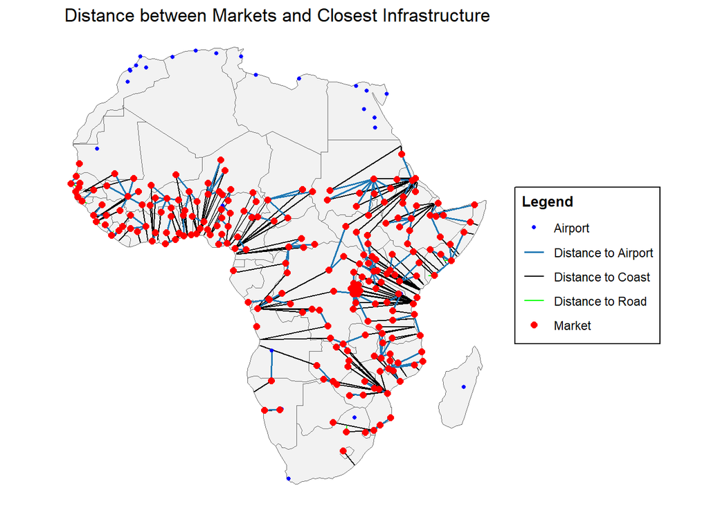

```r
ggplot() +
  geom_sf(data = africa, fill = "grey95", color = "grey40", linewidth = 0.3) +

  geom_sf(data = lines_coast,   aes(color = "Distance to Coast"), linewidth = 0.4) +
  geom_sf(data = lines_road,    aes(color = "Distance to Road"),  linewidth = 0.4) +
  geom_sf(data = lines_airport, aes(color = "Distance to Airport"), linewidth = 0.6) +
  geom_sf(data = airports_africa, aes(color = "Airport"), size = 1) +
  geom_sf(data = mkt_pts,         aes(color = "Market"),  size = 2) +

  scale_color_manual(
    name = "Legend",
    values = c(
      "Market"              = "red",
      "Airport"             = "blue",
      "Distance to Coast"   = "black",
      "Distance to Road"    = "green",
      "Distance to Airport" = "#1f78b4"
      )
    ) +
  labs(title = "Distance between Markets and Closest Infrastructure") +
  theme_void() +
  theme(
    plot.title = element_text(hjust = 0.5),

    legend.position = "right",
    legend.background = element_rect(fill = "white", color = "black", linewidth = 0.5),
    legend.margin = margin(t = 5, r = 5, b = 5, l = 5),
    legend.title = element_text(face = "bold", size = 10)
  )
```

## Q2.3: Scatterplots

### Constructing and merging the data

First, we obtain the price data from the replication package and compute, for each market, the average price across all time periods and across all crops. The raw price data contain multiple columns corresponding to different time periods. Some observations contain many `NA` or 0 values, for which we convert all to `NA` and calculate the average price over all available time periods.

```r
# import dataset from excel sheet
prices_raw <- read_excel("Data/markets/MktPrices.xlsx", sheet = "Sheet1")

# extract all the numeric column names (prices)
price_cols <- names(prices_raw)[grep("^\\d+$", names(prices_raw))]

avg_prices <- prices_raw %>%
  mutate(
    across(all_of(price_cols), ~ na_if(., 0)),
    price = rowMeans(pick(all_of(price_cols)), na.rm=T)
    ) %>%
  group_by(mktcode) %>%
  summarize(avg_price = mean(price, na.rm=T))
```

Once we have obtained the average values we can merge the two datasets by `mktcode`

```r
mkt_pts <- mkt_pts %>%
  left_join(avg_prices, by = "mktcode")
```

### Constructing the plots

We construct three scatter plots relating average market prices to the minimum distance to the coast, the nearest road, and the nearest airport.

#### Average Prices vs Distance to Coast

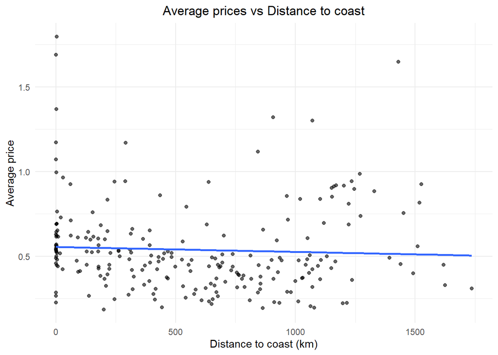

```r
ggplot(st_drop_geometry(mkt_pts), aes(x = dist_coast_km, y = avg_price)) +
  geom_point(alpha = 0.6) +
  geom_smooth(method = "lm", se = FALSE) +
  theme_minimal() +
  labs(x = "Distance to coast (km)", y = "Average price",
       title = "Average prices vs Distance to coast") +
  theme(plot.title = element_text(hjust=0.5))
```

#### Average Prices vs Distance to Road

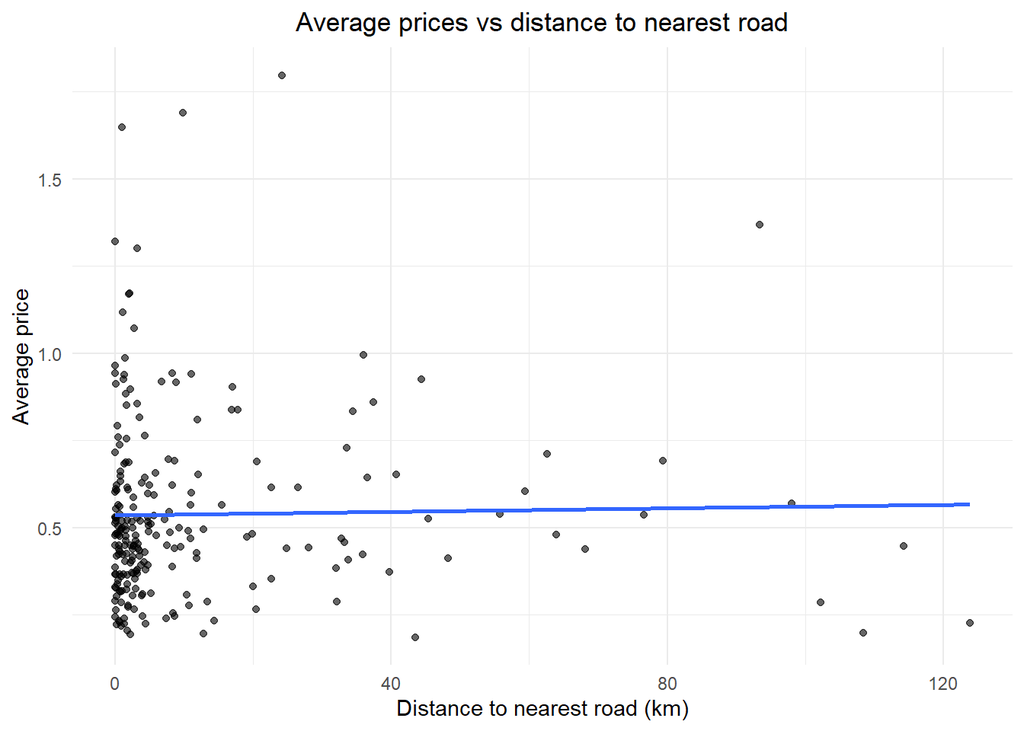

```r
ggplot(st_drop_geometry(mkt_pts), aes(x = dist_road_km, y = avg_price)) +
  geom_point(alpha = 0.6) +
  geom_smooth(method = "lm", se = FALSE) +
  theme_minimal() +
  labs(x = "Distance to nearest road (km)", y = "Average price",
       title = "Average prices vs distance to nearest road") +
  theme(plot.title = element_text(hjust=0.5))
```

#### Average Prices vs Distance to Airport

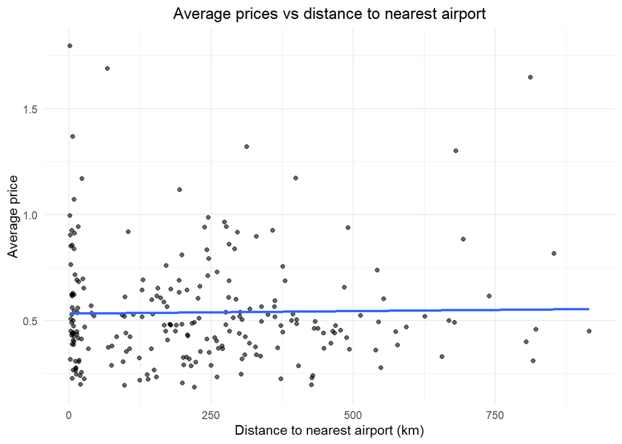

```r
ggplot(st_drop_geometry(mkt_pts), aes(x = dist_airport_km, y = avg_price)) +
  geom_point(alpha = 0.6) +
  geom_smooth(method = "lm", se = FALSE) +
  theme_minimal() +
  labs(x = "Distance to nearest airport (km)", y = "Average price",
       title = "Average prices vs distance to nearest airport") +
  theme(plot.title = element_text(hjust=0.5))
```

Back to top